# Model Theo

[figure not shown]

```
# Base Data Science snippet
import pandas as pd
import numpy as np
import matplotlib.pyplot as plt
import os
import time
from tqdm import tqdm_notebook

%matplotlib inline
%load_ext autoreload
%autoreload 2
```

```
import sys
sys.path.append("C:/git/case7-lockdown-exit-strategy/")

from covid.models import SIR,SEIR,SEIDR,SEIHDR
```

# Inspiration & Ressources

##### Epidemio models

- Beyond SIR modeling in Python https://towardsdatascience.com/infectious-disease-modelling-beyond-the-basic-sir-model-216369c584c4
- Modelling the coronavirus epidemic in a city with Python https://towardsdatascience.com/modelling-the-coronavirus-epidemic-spreading-in-a-city-with-python-babd14d82fa2
- Adding data to a SIR model https://www.lewuathe.com/covid-19-dynamics-with-sir-model.html
- ModÃ¨le Arthur Charpentier https://freakonometrics.hypotheses.org/60514

##### Neural ODEs

- How to solve an ODE with a Neural Network https://towardsdatascience.com/how-to-solve-an-ode-with-a-neural-network-917d11918932
- MIT model with ODEs https://trustmyscience.com/modele-predictif-mit-evalue-propagation-coronavirus-en-fonction-confinement/

# TODO

- What If Scenarios -> how to reach a peak, impact of lockdown exit, impact of mask - Fitting with real data - Age granularity - Regional granularity - Integrating hospital capacicity

# Simple models

## Simple SIR model

[figure not shown]

```
N = 1000

# Infects one person every day
beta = 1

# Infection lasts four days
gamma = 1/4

# Define model
sir = SIR(N,beta,gamma)

# Define first state
init_state = (990,10,0)

# Solve the equations
states = sir.solve(init_state)
states.head()
```

|  | S | I | R |
| --- | --- | --- | --- |
| 0 | 990.000000 | 10.000000 | 0.000000 |
| 1 | 975.480655 | 20.825692 | 3.693654 |
| 2 | 946.229625 | 42.465457 | 11.304918 |
| 3 | 890.413029 | 83.082093 | 26.504877 |
| 4 | 794.074208 | 150.793787 | 55.132005 |

The result is a custom object to ease visualization

```
type(states)
```

```
covid.models.states.CompartmentStates
```

```
states.show()
```

[interactive chart not shown]

```
states[["I","S","R"]].show_evolution_norm()
```

[interactive chart not shown]

## Simple SEIR model

[figure not shown]

```
# Population
N = 1e6

# How persons are infected per day
beta = 1

# Incubation time = 3 days
delta = 1/3

# Recovery time = 4 days
gamma = 1/4

# Define the model
seir = SEIR(N,beta,delta,gamma)

# Define the initial state
infected = 1
init_state = (N - infected,0,infected,0)

# Solve the equations
states = seir.solve(init_state)
states.head()
```

|  | S | E | I | R |
| --- | --- | --- | --- | --- |
| 0 | 999999.000000 | 0.000000 | 1.000000 | 0.000000 |
| 1 | 999998.069288 | 0.789438 | 0.908596 | 0.232678 |
| 2 | 999997.112121 | 1.382625 | 1.033284 | 0.471971 |
| 3 | 999995.955104 | 1.981000 | 1.302670 | 0.761226 |
| 4 | 999994.462835 | 2.697977 | 1.704893 | 1.134295 |

```
states[["I","E","S","R"]].explore()
```

[interactive chart not shown]

## Simple SEIDR model

[figure not shown]

```
# Population
N = 1e6

# Recovery time = 4 days
gamma = 1/4

# How persons are infected per day
R0 = 5
beta = gamma * R0

# Incubation time = 3 days
delta = 1/3

# Dead compartments
alpha = 0.2 # probability to die
rho = 1/9 # 9 ndays before death

# Define the model
seidr = SEIDR(N,beta,delta,gamma,rho,alpha)

# Define the initial state
exposed = 1
init_state = (N - exposed,exposed,0,0,0)

# Solve the equations
states = seidr.solve(init_state)
states.head()
```

|  | S | E | I | D | R |
| --- | --- | --- | --- | --- | --- |
| 0 | 999999.000000 | 1.000000 | 0.000000 | 0.000000 | 0.000000 |
| 1 | 999998.820587 | 0.876991 | 0.270527 | 0.003190 | 0.028706 |
| 2 | 999998.340266 | 1.043554 | 0.498893 | 0.011729 | 0.105558 |
| 3 | 999997.557418 | 1.421301 | 0.764822 | 0.025646 | 0.230814 |
| 4 | 999996.389310 | 2.022357 | 1.124209 | 0.046412 | 0.417711 |

```
states[["E","I","D","S","R"]].explore()
```

[interactive chart not shown]

```
seidr.network.show()
```

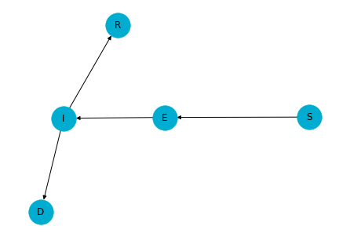

## Simple SEIHDR model

We add the hospitalization

```
1/4 * 2.5
```

```
0.625
```

[output not shown]

|  | S | E | I | H | D | R |
| --- | --- | --- | --- | --- | --- | --- |
| 0 | 999999.000000 | 1.000000 | 0.000000 | 0.000000 | 0.000000 | 0.000000 |
| 1 | 999998.886380 | 0.924993 | 0.174993 | 0.008439 | 0.000065 | 0.005130 |
| 2 | 999998.570010 | 1.047002 | 0.331390 | 0.029711 | 0.000469 | 0.021419 |
| 3 | 999998.050955 | 1.330911 | 0.504248 | 0.061311 | 0.001461 | 0.051113 |
| 4 | 999997.290947 | 1.782580 | 0.721386 | 0.103973 | 0.003275 | 0.097839 |

```
states[["E","I","H","D","S","R"]].explore()
```

[interactive chart not shown]

```
seihdr.network.show()
```

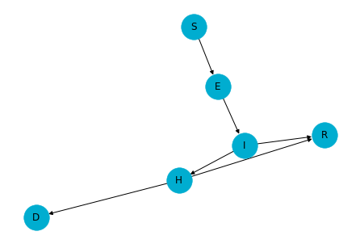

# Exploring policies

## Simple lockdown policy on SEIHDR model

```
# Constants
N = 1e6 # population
gamma = 1/4 # rate of infection
delta = 1/3 # incubation time
theta = 1/5 # ndays before complication
kappa = 1/10 # ndays before symptoms disappear
phi = 0.5 # probability of complications
alpha = 0.2 # probability to die
rho = 1/9 # 9 ndays before death

# Define the initial state
exposed = 1
init_state = (N - exposed,exposed,0,0,0,0)

# Policy simulation
lockdown_after = 20
beta_high = gamma * 5
beta_low = [gamma * 5,gamma * 2.5,gamma * 0.9]
def beta_lockdown(y,t,beta_low):
    if t < lockdown_after:
        return beta_high
    else:
        return beta_low


for b in beta_low:

    # Define the model
    seihdr = SEIHDR(N,lambda y,t : beta_lockdown(y,t,b),delta,gamma,rho,alpha,theta,phi,kappa)

    # Solve the equations
    states = seihdr.solve(init_state,n_days = 100)
    print("---------------------------------------")
    print(f"Lockdown at {lockdown_after} with R0={b/gamma}")
    states.show_peak(show = True)
    print(f"- Max hospitals {int(states['H'].max())} at day {states['H'].idxmax()}")
    print("")
```

```
---------------------------------------
Lockdown at 20 with R0=5.0
```

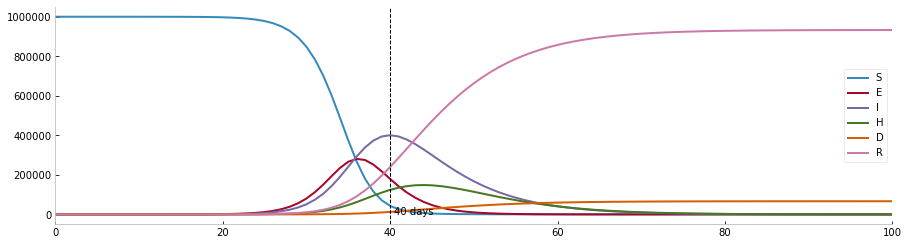

```
- Max hospitals 148667 at day 44

---------------------------------------
Lockdown at 20 with R0=2.5
```

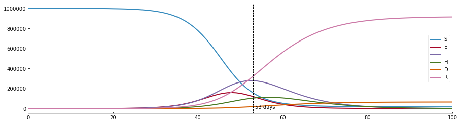

```
- Max hospitals 112637 at day 57

---------------------------------------
Lockdown at 20 with R0=0.9
```

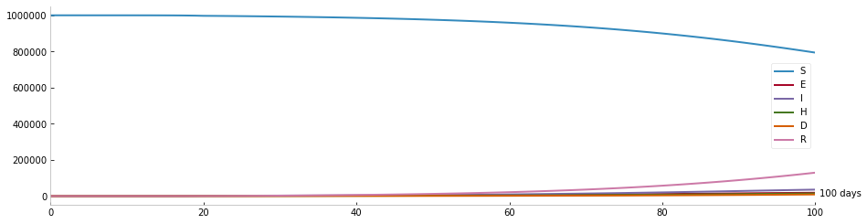

```
- Max hospitals 14464 at day 100
```

Let's see impact of delaying lockdown

```
# Constants
N = 1e6 # population
gamma = 1/4 # rate of infection
delta = 1/3 # incubation time
theta = 1/5 # ndays before complication
kappa = 1/10 # ndays before symptoms disappear
phi = 0.5 # probability of complications
alpha = 0.2 # probability to die
rho = 1/9 # 9 ndays before death

# Define the initial state
exposed = 1
init_state = (N - exposed,exposed,0,0,0,0)

# Policy simulation
lockdown_after = [10,20,30,40,50,80]
beta_high = gamma * 5
beta_low = gamma * 0.9
def beta_lockdown(y,t,start):
    if t < start:
        return beta_high
    else:
        return beta_low


for l in lockdown_after:

    # Define the model
    seihdr = SEIHDR(N,lambda y,t : beta_lockdown(y,t,l),delta,gamma,rho,alpha,theta,phi,kappa)

    # Solve the equations
    states = seihdr.solve(init_state,n_days = 100)

    print("---------------------------------------")
    print(f"Lockdown at {l} with R0={b/gamma}")
    states.show_peak(show = True)
    print(f"- Max hospitals {int(states['H'].max())} at day {states['H'].idxmax()}")
    print("")
```

```
---------------------------------------
Lockdown at 10 with R0=0.9
```

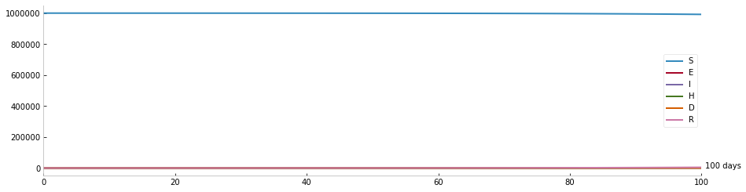

```
- Max hospitals 639 at day 100

---------------------------------------
Lockdown at 20 with R0=0.9
```

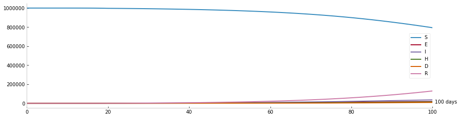

```
- Max hospitals 14464 at day 100

---------------------------------------
Lockdown at 30 with R0=0.9
```

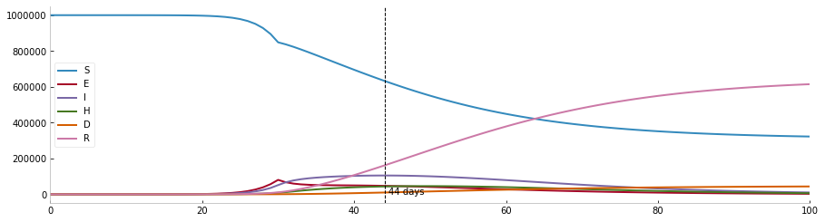

```
- Max hospitals 45637 at day 49

---------------------------------------
Lockdown at 40 with R0=0.9
```

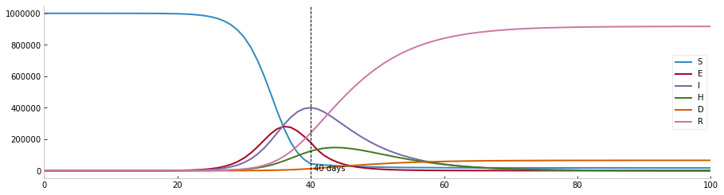

```
- Max hospitals 146938 at day 44

---------------------------------------
Lockdown at 50 with R0=0.9
```

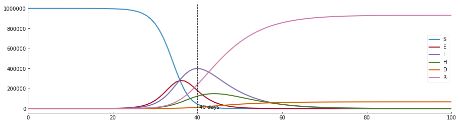

```
- Max hospitals 148667 at day 44

---------------------------------------
Lockdown at 80 with R0=0.9
```

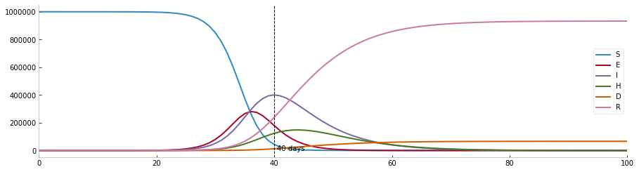

```
- Max hospitals 148667 at day 44
```

## Gradual lockdown policy with sigmoid

To illustrate a gradual policy we will use the function below  
The parameter duration allows to decide how long it takes to make a 95% shift in the sigmoid, ie how long for the policy to be asymptotically implemented around the inflection point at `(end - start) / 2`

```
from covid.policies.utils import sigmoid_response
from covid.policies.utils import multiple_sigmoid_response
```

```
x = np.linspace(0,100)
start = 2
end = 1
start_date = 30
plt.figure(figsize = (15,4))
for duration in [2,7,14,30]:
    plt.plot(x,sigmoid_response(x,start_date - duration/2,start,end,duration),label = duration)
plt.legend()
plt.show()
```

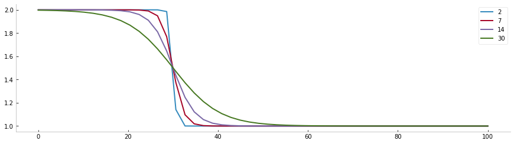

Without offseting the inflection point, it's actually starting at the start date to simulate when a policy is implemented

```
x = np.linspace(0,100)
start = 2
end = 1
start_date = 30
plt.figure(figsize = (15,4))
for duration in [2,7,14,30]:
    plt.plot(x,sigmoid_response(x,start_date,start,end,duration),label = duration)
plt.legend()
plt.show()
```

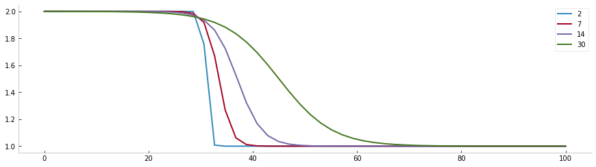

Now let's implemented this gradual lockdown policy

```
# Constants
N = 1e6 # population
gamma = 1/4 # rate of infection
delta = 1/3 # incubation time
theta = 1/5 # ndays before complication
kappa = 1/10 # ndays before symptoms disappear
phi = 0.5 # probability of complications
alpha = 0.2 # probability to die
rho = 1/9 # 9 ndays before death

# Define the initial state
infected = 1
init_state = (N - infected,0,infected,0,0,0)

# Policy simulation
lockdown_after = [10,20,25,30,35,40]
beta_high = gamma * 5
beta_low = gamma * 0.9
lockdown_implementation_days = 6

def beta_lockdown(y,t,l):
    return sigmoid_response(t,l,beta_high,beta_low,lockdown_implementation_days)


for l in lockdown_after:

    # Define the model
    seihdr = SEIHDR(N,lambda y,t : beta_lockdown(y,t,l),delta,gamma,rho,alpha,theta,phi,kappa)

    # Solve the equations
    states = seihdr.solve(init_state,n_days = 100)
    print("---------------------------------------")
    print(f"Lockdown at day {l} with R0={b/gamma}")
    states.show_peak()
    print(f"- Max hospitals {int(states['H'].max())} at day {states['H'].idxmax()}")
    print("")
```

```
---------------------------------------
Lockdown at day 10 with R0=0.9
```

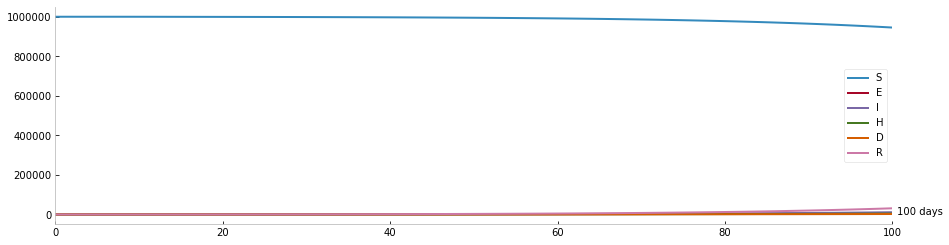

```
- Max hospitals 4201 at day 100

---------------------------------------
Lockdown at day 20 with R0=0.9
```

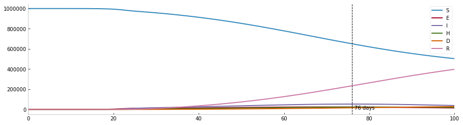

```
- Max hospitals 23402 at day 80

---------------------------------------
Lockdown at day 25 with R0=0.9
```

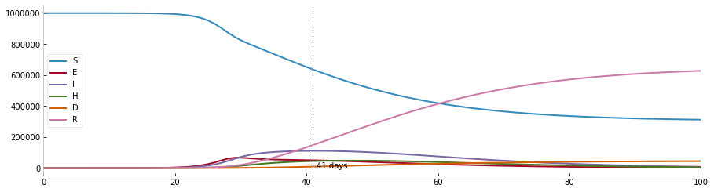

```
- Max hospitals 48029 at day 47

---------------------------------------
Lockdown at day 30 with R0=0.9
```

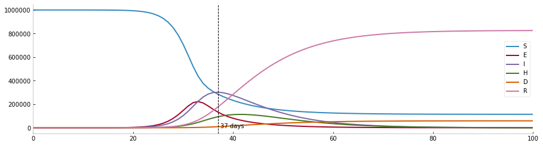

```
- Max hospitals 113411 at day 41

---------------------------------------
Lockdown at day 35 with R0=0.9
```

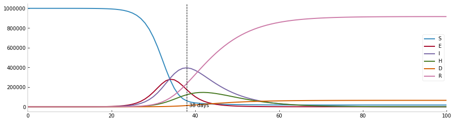

```
- Max hospitals 145902 at day 42

---------------------------------------
Lockdown at day 40 with R0=0.9
```

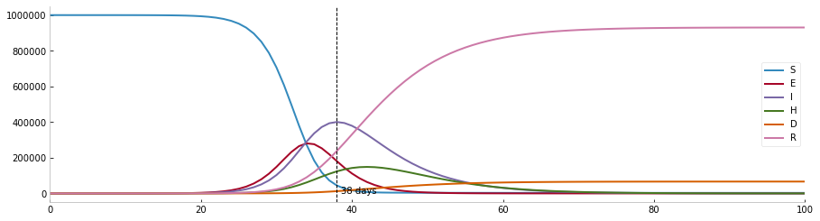

```
- Max hospitals 148631 at day 42
```

## Simple lockdown exit strategy

For the exit strategy we need a double sigmoid, we will use the `multiple_sigmoid_response` function  
We can build complex response curves

```
x = np.linspace(0,100)

start_value = 2
values = [1,0.2,3,1.5]
dates = [10,30,50,80]
durations = [3,10,11,4]

y = multiple_sigmoid_response(x,start_value,values,dates,durations)


plt.figure(figsize = (15,4))
plt.plot(x,y)
plt.show()
```

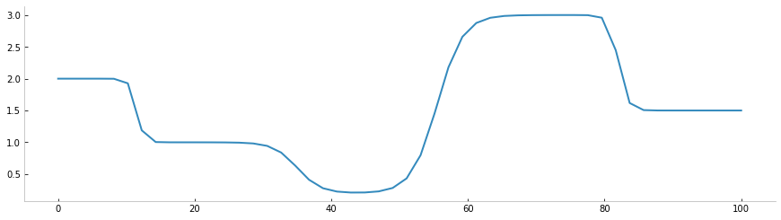

For an exit strategy we model a beta that go up again when the lockdown is finished

```
x = np.linspace(0,100)

start_value = 2
values = [0.5,2]
dates = [30,90]
durations = 5

y = multiple_sigmoid_response(x,start_value,values,dates,durations)

plt.figure(figsize = (15,4))
plt.plot(x,y)
plt.show()
```

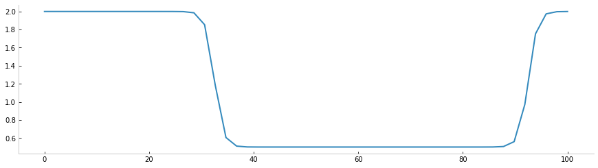

Let's put this function in the SEIHDR model

```
# Constants
N = 1e6 # population
gamma = 1/4 # rate of infection
delta = 1/3 # incubation time
theta = 1/5 # ndays before complication
kappa = 1/10 # ndays before symptoms disappear
phi = 0.5 # probability of complications
alpha = 0.2 # probability to die
rho = 1/9 # 9 ndays before death

# Define the initial state
exposed = 1
init_state = (N - exposed,exposed,0,0,0,0)

# Policy simulation
lockdown_after = 25
beta_high = gamma * 5
beta_low = gamma * 0.9
betas = [beta_low,beta_high]
lockdown_implementation_days = 6

def beta_lockdown(y,t,exit):
    return multiple_sigmoid_response(t,beta_high,betas,[lockdown_after,exit],lockdown_implementation_days)

for duration in [120,90,60,30,10]:

    exit = lockdown_after + duration

    # Define the model
    seihdr = SEIHDR(N,lambda y,t : beta_lockdown(y,t,exit),delta,gamma,rho,alpha,theta,phi,kappa)

    # Solve the equations
    states = seihdr.solve(init_state,n_days = 200)
    print("---------------------------------------")
    print(f"Lockdown at day {lockdown_after} with R0={b/gamma} for {duration} days")
    states.show_peak(show = False)
    plt.axvline(x = lockdown_after,lw = 3,color = "red")
    plt.axvline(x = exit,lw = 3,color = "red")
    plt.show()
    print(f"- Max hospitals {int(states['H'].max())} at day {states['H'].idxmax()}")
    print("")
```

```
---------------------------------------
Lockdown at day 25 with R0=0.9 for 120 days
```

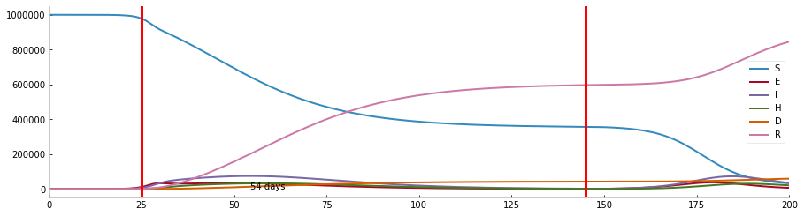

```
- Max hospitals 33140 at day 59

---------------------------------------
Lockdown at day 25 with R0=0.9 for 90 days
```

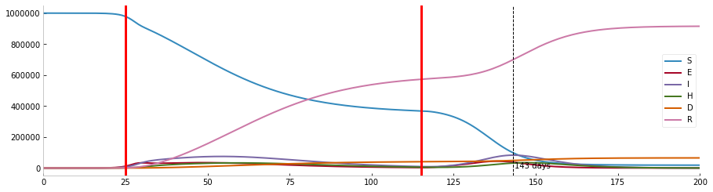

```
- Max hospitals 34671 at day 147

---------------------------------------
Lockdown at day 25 with R0=0.9 for 60 days
```

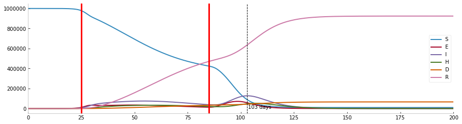

```
- Max hospitals 52026 at day 107

---------------------------------------
Lockdown at day 25 with R0=0.9 for 30 days
```

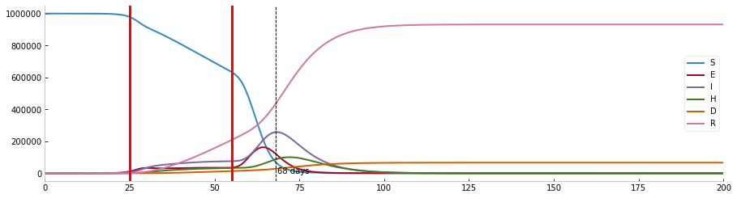

```
- Max hospitals 100823 at day 72

---------------------------------------
Lockdown at day 25 with R0=0.9 for 10 days
```

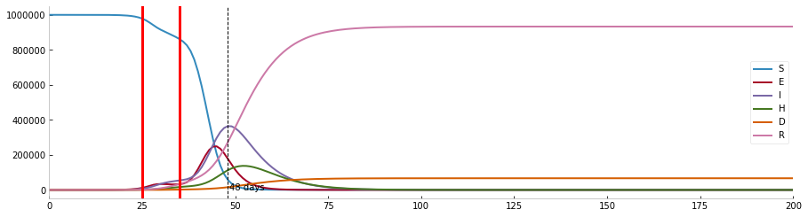

```
- Max hospitals 137364 at day 52
```

# Playground

## Network draw shape

```
import networkx as nx
```

```
pos=nx.spectral_layout(seidr.network.graph)
```

```
pos
```

```
{'S': array([ 9.93364820e-01, -3.16250152e-16]),
 'E': array([ 4.78001493e-01, -9.42055475e-17]),
 'I': array([-2.85351731e-01,  1.27839057e-16]),
 'D': array([-0.59300729, -1.        ]),
 'R': array([-0.59300729,  1.        ])}
```

```
A = np.array(list(pos.values()))
```

```
def create_angle(pos):
    A = np.array(list(pos.values()))
    th = np.arctan2(*(A[1] - A[0])) - np.pi * 0.5
    c = np.cos(th)
    s = np.sin(th)
    th = np.array([[c,-s],[s,c]])
    return th
```

```
A2 = A.dot(create_angle(pos).T)
pos2 = {k:A2[i] for i,k in enumerate("SEIDR")}
pos2
```

```
{'S': array([-9.93364820e-01, -2.46544551e-16]),
 'E': array([-4.78001493e-01, -1.76608058e-16]),
 'I': array([2.85351731e-01, 3.38280757e-17]),
 'D': array([0.59300729, 1.        ]),
 'R': array([ 0.59300729, -1.        ])}
```

```
nx.draw_spectral(seidr.network.graph)
```

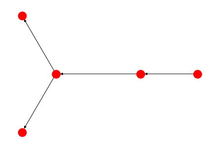

```
nx.draw(seidr.network.graph,pos = pos2)
```

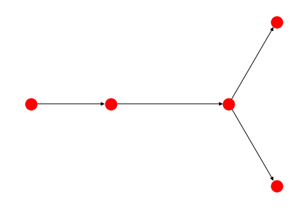

```
from covid.models.network import CompartmentNetwork
```

```
G = CompartmentNetwork(["S","I","R"])
```

```
G.compute_derivatives(["S","I","R"],1,1)
```

```
[0, 0, 0]
```

```
G.add_edge("S","I",1,1,lambda y,t:t)
```

```
G.get_transition("S","I",None,3)
```

```
3
```

```
G.show()
```

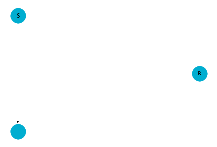

```
G.get_derivative("R")
```

```
-1
```

```
f = lambda y,t: 1
```

```
def test(y,t):
    return 1
```

```
callable(test)
```

```
True
```